# Species distribution modeling and landscape genetics of P. benedetti

Connor French

## Intro

This is a report containing all analyses for the species distribution modeling and landscape genetics portions of Sniffin et al. The first portion contains modified output from [Wallace](https://wallaceecomod.github.io/), a platform for species distribution modeling. Followed are analyses and figures for landscape genetics. Wallace automatically outputs a `.Rmd` file, which I’ve modified to include the rest of the analyses. If coding and commenting conventions seem to jump around, this is why.

### Package installation

The following R packages must be installed and loaded before starting.

```r
library(spocc)
library(spThin)
library(dismo)
library(rgeos)
library(ENMeval)
library(dplyr)
library(ggplot2)
library(ggspatial)
library(gdistance)
library(readr)
library(sf)
library(rnaturalearth)
library(patchwork)
library(here)
library(adegenet)
library(dartR)
library(vcfR)
```

Wallace also includes several functions developed to help integrate different packages and some additional functionality. For this reason, it is necessary to load the file `functions.R`, The function `system.file()` finds this script, and `source()` loads it.

```r
source(system.file('shiny/funcs', 'functions.R', package = 'wallace'))
```

## Species distribution modeling

Read in occurrence data.

```r
# create path to user occurrences csv file
userOccs.path <- here("data", "sample_latlongs.csv")

# read in csv
userOccs.csv <- read.csv(userOccs.path, header = TRUE)

# remove rows with duplicate coordinates
occs.dups <- duplicated(userOccs.csv[c('longitude', 'latitude')])
occs <- userOccs.csv[!occs.dups, ]

# remove NAs
occs <- occs[complete.cases(occs$longitude, occs$latitude),]

# give all records a unique ID
occs$occID <- row.names(occs)
```

### Process Occurrence Data

Spatial thinning selected. Thin distance selected is 5 km.

```r
set.seed(273)
output <-
  spThin::thin(
    occs,
    'latitude',
    'longitude',
    'name',
    thin.par = 5,
    reps = 100,
    locs.thinned.list.return = TRUE,
    write.files = FALSE,
    verbose = FALSE
  )
```

Since spThin did 100 iterations, there are 100 different variations of how it thinned your occurrence localities. As there is a stochastic element in the algorithm, some iterations may include more localities than the others, and we need to make sure we maximize the number of localities we proceed with.

```r
# find the iteration that returns the max number of occurrences
maxThin <- which(sapply(output, nrow) == max(sapply(output, nrow)))

# if there's more than one max, pick the first one
maxThin <-
  output[[ifelse(length(maxThin) > 1, maxThin[1], maxThin)]]

# subset occs to match only thinned occs
occs <- occs[as.numeric(rownames(maxThin)), ]

# write thinned occs to spreadsheet
thin_occs_dir <- here("output", "spreadsheets", "thinned_occs.csv")
write_csv(occs, thin_occs_dir)
```

### Obtain Environmental Data

Only considering bio1, bio5, bio6, bio10, bio11, bio12, bio13, and bio14 after assessing the correlation among rasters and removing ecologically irrelevant variables that have a correlation > 0.7 with more ecologically relevant variables.

```r
d.envs <- here("data", "current_climate")

# create paths to the raster files
userRas.paths <-
  file.path(
    d.envs,
    c(
      'bio1.tif',
      'bio5.tif',
      'bio6.tif',
      'bio10.tif',
      'bio11.tif',
      'bio12.tif',
      'bio13.tif',
      'bio14.tif'
    )
  )

# make a RasterStack out of the raster files
envs <- raster::stack(userRas.paths)
```

### Process Environmental Data

Background selection technique chosen as Minimum Convex Polygon.

```r
occs.xy <- occs[c('longitude', 'latitude')]
sp::coordinates(occs.xy) <- ~ longitude + latitude
bgExt <- mcp(occs.xy)
```

Buffer size of the study extent polygon defined as 0.5 degrees.

```r
bgExt <- rgeos::gBuffer(bgExt, width = 0.5)
```

```r
set.seed(2354)
# crop the environmental rasters by the background extent shape
envsBgCrop <- raster::crop(envs, bgExt)
# mask the background extent shape from the cropped raster
envsBgMsk <- raster::mask(envsBgCrop, bgExt)
# sample random background points. Sometimes throws an error "Error: attempt to run non-function"- the functions still runs correctly, so idk what happened
bg.xy <- dismo::randomPoints(envsBgMsk, 20000)
# convert matrix output to data frame
bg.xy <- as.data.frame(bg.xy)
# write background points to df
bg_dir <- here("output", "spreadsheets", "background_points.csv")
write_csv(bg.xy, bg_dir)
```

### Partition Occurrence Data

Occurrence data is now partitioned for cross-validation, a method that iteratively builds a model on all but one group and evaluates that model on the left-out group.

For example, if the data is partitioned into 3 groups A, B, and C, a model is first built with groups A and B and is evaluated on C. This is repeated by building a model with B and C and evaluating on A, and so on until all combinations are done.

Cross-validation operates under the assumption that the groups are independent of each other, which may or may not be a safe assumption for your dataset. Spatial partitioning is one way to ensure more independence between groups.

I’m partitioning using a jackknife approach, since our sample size is too low for a spatial blocking method to be effective.

```r
set.seed(18736)
occs.xy <- occs[c('longitude', 'latitude')]
group.data <- ENMeval::get.jackknife(occ = occs.xy, bg.coords = bg.xy)
```

```r
# pull out the occurrence and background partition group numbers from the list
occs.grp <- group.data[[1]]
bg.grp <- group.data[[2]]
```

### Build and Evaluate Niche Model

You selected the maxent model.

```r
set.seed(8372)
# define the vector of regularization multipliers to test
rms <- seq(0.5, 5, 0.5)
# iterate model building over all chosen parameter settings
e <-
  ENMeval::ENMevaluate(
    occs.xy,
    envsBgMsk,
    bg.coords = bg.xy,
    RMvalues = rms,
    fc = c('L', 'LQ', 'H', 'LQH'),
    method = 'user',
    occs.grp,
    bg.grp,
    clamp = TRUE,
    algorithm = "maxnet"
  )
# unpack the results data frame, the list of models, and the RasterStack of raw predictions
evalTbl <- e@results
evalMods <- e@models
names(evalMods) <- e@results$settings
evalPreds <- e@predictions

# write model output to file
model_path <- here("output", "model.RDS")
saveRDS(e, file = model_path)
```

View the response curve for environmental variables from the final model. In this case we only had one, bio1 (Average Annual Temperature).

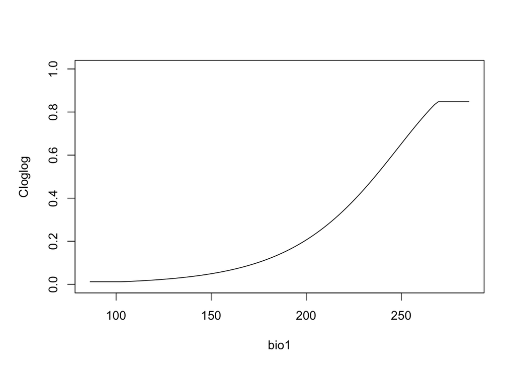

```r
# view response curves for environmental variables with non-zero coefficients
plot(evalMods[["L_2.5"]], vars = c('bio1'), type = "cloglog")
```

```r
# write response curve plot to file
resp_path <- here("output", "figures", "supp_fig_s2_resp_curve.pdf")
pdf(resp_path, width = 3.54, height = 3.0)
plot(evalMods[["L_2.5"]], vars = c('bio1'), type = "cloglog")
dev.off()
```

Take a look at the model results. I’m selecting models based on AICc, so this is what I’m plotting. There are many models within 2 AICc, but they are all fairly similar and retain a single variable. Just picking the top model since it is a simple model and it doesn’t change the results much qualitatively or quantitatively.

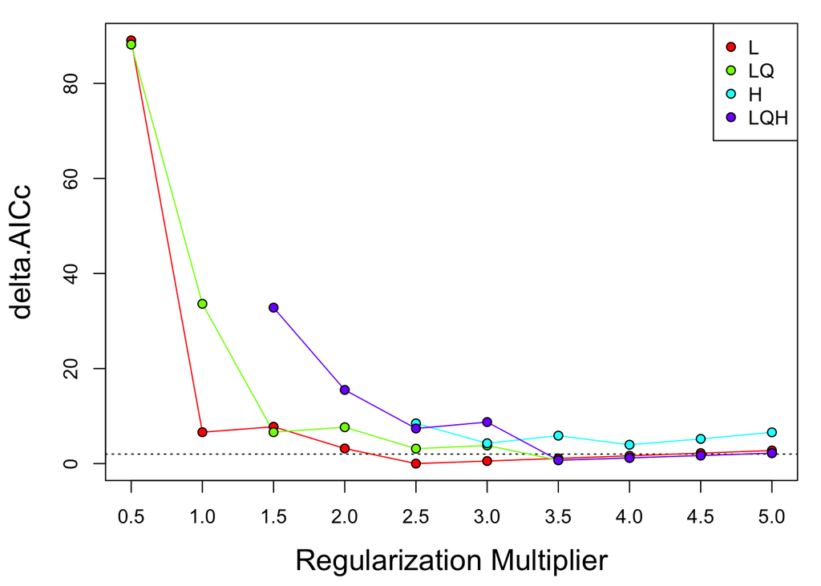

```r
# view ENMeval results
ENMeval::eval.plot(evalTbl, value = "delta.AICc")
```

```r
# Select your model from the models list
mod <- evalMods[["L_2.5"]]
```

Predict model to original background area plus Colima.

```r
# add colima to the background extent to extend prediction area
colima <-
  rnaturalearth::ne_states(country = "Mexico", returnclass = "sf") %>%
  filter(name == "Colima") %>%
  st_crop(
    xmin = -106,
    ymin = 20,
    xmax = 106,
    ymax = -18
  )
bgExt_sf <- st_as_sf(bgExt)
st_crs(bgExt_sf) <- "+proj=longlat +datum=WGS84 +no_defs"


bg_colima <- st_union(bgExt_sf, colima) %>%
  st_convex_hull()

# crop the environmental rasters by the background extent shape
envsBgCrop_col <- raster::crop(envs, bg_colima)
# mask the background extent shape from the cropped raster
envsBgMsk_col <- raster::mask(envsBgCrop_col, bg_colima)

# generate cloglog prediction
pred <-
  ENMeval::maxnet.predictRaster(mod, envsBgMsk_col, type = 'cloglog', clamp = TRUE)

crs(pred) <- '+proj=longlat +ellps=WGS84 +datum=WGS84 +no_defs'

#write prediction to file
pred_path <- here("output", "rasters", "current_projection.tif")
raster::writeRaster(pred, filename = pred_path, format = "GTiff", overwrite = TRUE)
```

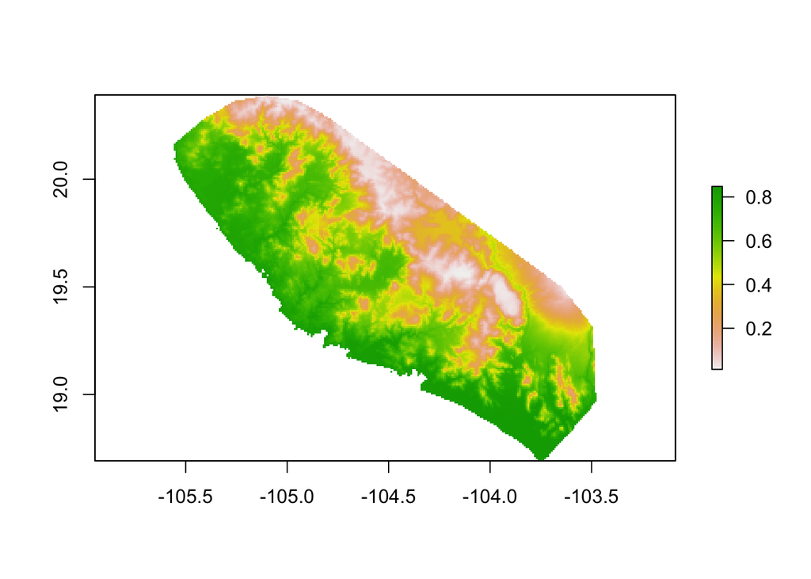

```r
plot(pred)
```

MESS map. It looks like most possible dispersal paths within their dispersal limits are analogous climate. A landscape genetics analysis with LGM climate would be reasonable.

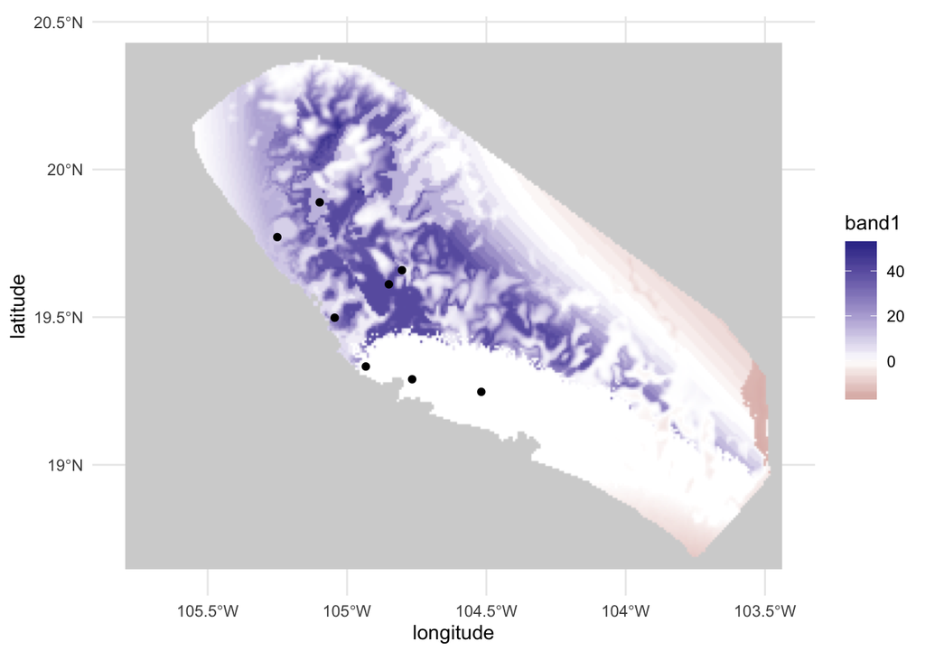

```r
bg_xy <- raster::as.data.frame(envsBgMsk) %>% na.omit()

current_mess <- dismo::mess(envsBgMsk_col, bg_xy)

crs(current_mess) <-
  '+proj=longlat +ellps=WGS84 +datum=WGS84 +no_defs'

ggplot() +
  ggspatial::layer_spatial(data = current_mess) +
  scale_fill_gradient2(na.value = "lightgrey") +
  geom_point(data = occs, aes(x = longitude, y = latitude)) +
  theme_minimal()
```

```r
# write mess raster to file
mess_rast_out <- here("output", "rasters", "current_mess.tif")
writeRaster(current_mess, mess_rast_out, format = "GTiff", overwrite = TRUE)
```

Thresholded model prediction for current climate. Thresholded by the minimum 10th percentile training presence. This threshold is more conservative then the minimum training presence value, although it likely converges the the MTP given the low number of training localities.

```r
# get predicted values for occurrence grid cells
occPredVals <- raster::extract(pred, occs.xy)
# define minimum training presence threshold
thr <- thresh(occPredVals, "p10")
# threshold model prediction
pred_p10 <- pred > thr

#write threshold model prediction to file
thresh_path <-
  here("output", "rasters", "thresh_p10_current_pred.tif")
raster::writeRaster(pred_p10, filename = thresh_path, format = "GTiff", overwrite = TRUE)
```

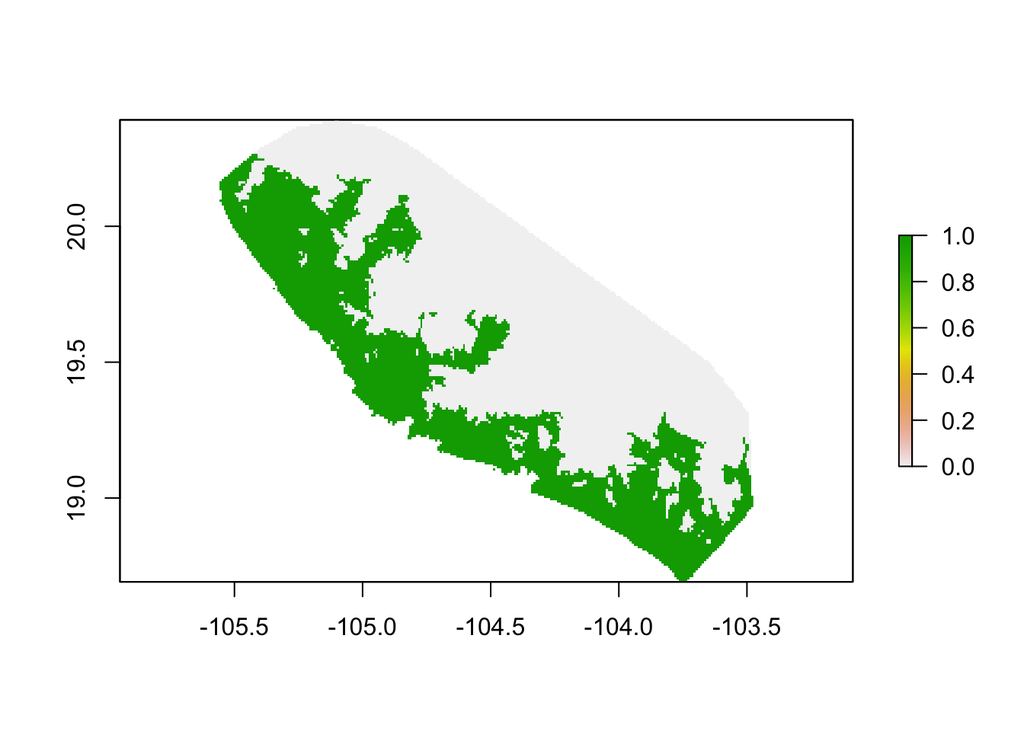

```r
# plot the model prediction
plot(pred_p10)
```

Project to the lgm.

```r
lgm_path <- here("data", "lgm_climate")

lgm_layers <- file.path(
  lgm_path,
  c(
    'bio1.tif',
    'bio5.tif',
    'bio6.tif',
    'bio10.tif',
    'bio11.tif',
    'bio12.tif',
    'bio13.tif',
    'bio14.tif'
  )
) %>%
  raster::stack() %>%
  raster::crop(bg_colima) %>%
  raster::mask(bg_colima)

# generate cloglog prediction
lgm_pred <-
  ENMeval::maxnet.predictRaster(mod, lgm_layers, type = 'cloglog', clamp = TRUE)

crs(lgm_pred) <- '+proj=longlat +ellps=WGS84 +datum=WGS84 +no_defs'
```

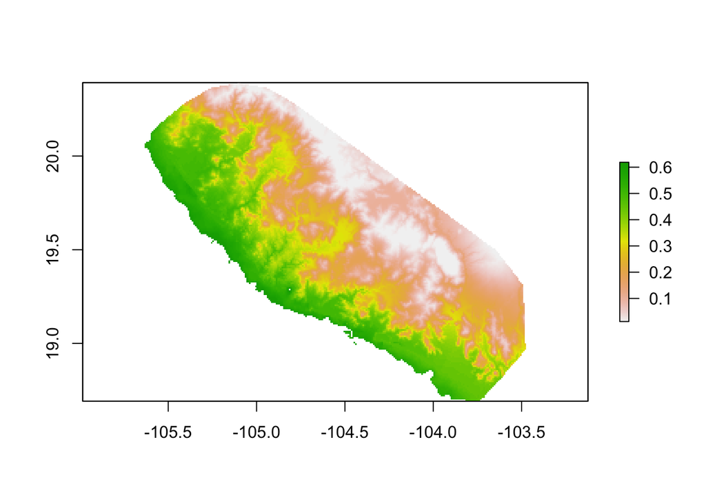

```r
plot(lgm_pred)
```

MESS map. It looks like most possible dispersal paths within their dispersal limits are analogous climate. A landscape genetics analysis with LGM climate would be reasonable.

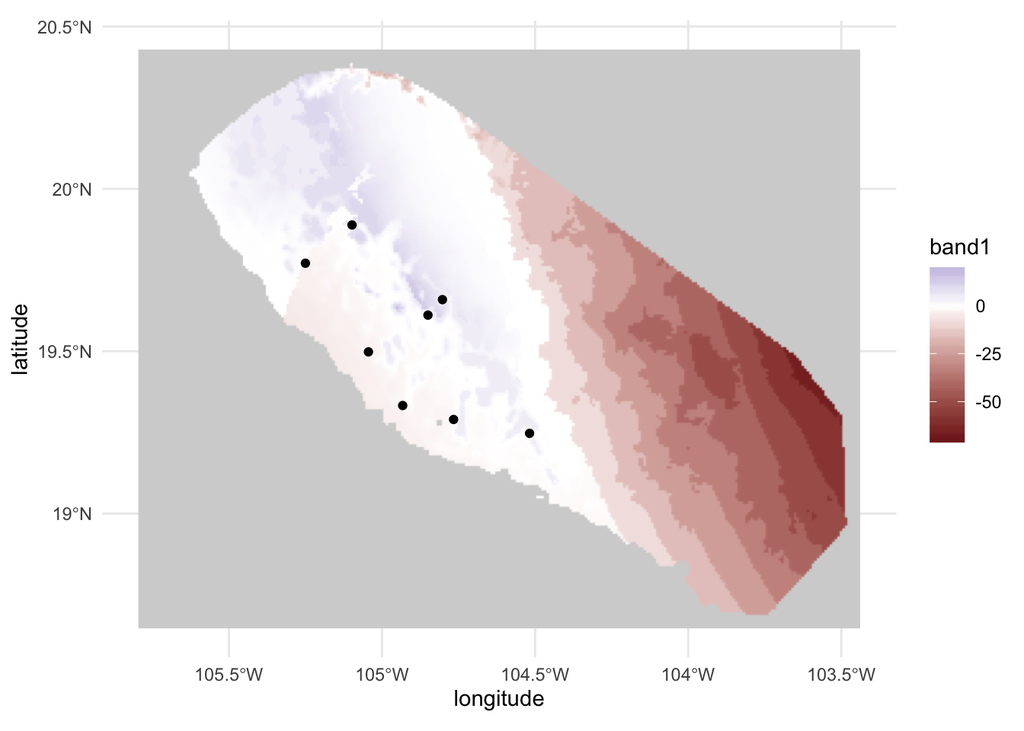

```r
lgm_mess <- dismo::mess(lgm_layers, bg_xy)

crs(lgm_mess) <- '+proj=longlat +ellps=WGS84 +datum=WGS84 +no_defs'

ggplot() +
  ggspatial::layer_spatial(data = lgm_mess) +
  scale_fill_gradient2(na.value = "lightgrey") +
  geom_point(data = occs, aes(x = longitude, y = latitude)) +
  theme_minimal()
```

LGM 10th percentile thresholded map.

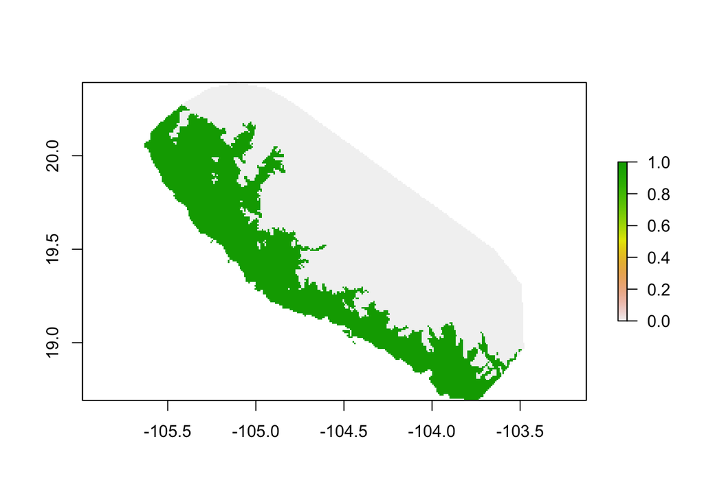

```r
# get predicted values for occurrence grid cells
occPredVals_lgm <- raster::extract(lgm_pred, occs.xy)
# define minimum training presence threshold
thr_lgm <- thresh(occPredVals_lgm, "p10")
# threshold model prediction
lgm_p10 <- lgm_pred > thr_lgm

plot(lgm_p10)
```

Write lgm projection and mess map to files.

```r
lgm_out_path <- here("output", "rasters")

raster::writeRaster(
  lgm_pred,
  filename = file.path(lgm_out_path, "lgm_projection.tif"),
  format = "GTiff",
  overwrite = TRUE
)

 raster::writeRaster(
   lgm_mess,
   filename = file.path(lgm_out_path, "lgm_mess.tif"),
   format = "GTiff",
   overwrite = TRUE
   )

raster::writeRaster(
  lgm_p10,
  filename = file.path(lgm_out_path, "thresh_p10_lgm_pred.tif"),
  format = "GTiff",
  overwrite = TRUE
)
```

Generate friction surface for landscape genetics. Using the rSPD method because it allows users to specify the amount of randomness in the walk (e.g. following a least-cost path vs a totally random walk). Given that we don’t know much about how geckos traverse the landscape and the landscape is broken into large cell sizes relative to an individual gecko’s dispersal decision-making, I’m setting the dispersal kernel close to random.

```r
#read in all localities where there is genetic sampling
gen_locs_path <- here("data", "sample_latlongs.csv")
gen_locs <-
  read.csv(gen_locs_path) %>%
  dplyr::select(longitude, latitude) %>%
  filter(!duplicated(longitude)) # single observation per locality for distance calculations

coordinates(gen_locs) <- ~ longitude + latitude

#geographic distances for pure IBD hypothesis
geo_dist <- raster::pointDistance(gen_locs, lonlat = TRUE) %>%
  as.dist()

###transition matrices with geographic corrections
tr_current <- pred %>%
  spatialEco::raster.invert() %>%  #invert the SDM values
  gdistance::transition(mean, directions = 8) %>%  #create a transition matrix
  gdistance::geoCorrection("r", scl = TRUE) #correct for geographic distortion


tr_lgm <- lgm_pred %>%
  spatialEco::raster.invert() %>%  #invert the SDM values
  gdistance::transition(mean, directions = 8) %>%  #create a transition matrix
  gdistance::geoCorrection("r", scl = TRUE) #correct for geographic distortion

#calculate resistance distance with rSPD
spd_current <-
  gdistance::rSPDistance(
    tr_current,
    from = gen_locs,
    to = gen_locs,
    theta = 1e-12,
    totalNet = "total",
    method = 1
  )

spd_lgm <-
  gdistance::rSPDistance(
    tr_lgm,
    from = gen_locs,
    to = gen_locs,
    theta = 1e-12,
    totalNet = "total",
    method = 1
  )

dist_path <- here("output", "spreadsheets")
### Write geographic distance matrix to file
write.table(geo_dist %>% as.matrix(),
            file = file.path(dist_path, "geo_distance_matrix.txt"))

### Write resistance matrices to file
write.table(spd_current %>% as.matrix(),
            file = file.path(dist_path, "resistance_dist_current.txt"))


write.table(spd_lgm %>% as.matrix(),
            file = file.path(dist_path, "resistance_dist_lgm.txt"))
```

Calculate a pairwise Fst matrix for our genetic distance matrix. I set `eval=FALSE` to prevent this from running when rendering the document. The `dartR::gl.fst.pop()` function takes forever to run. I’d recommend running it as a background process or when you don’t need the computer for a while.

```r
data_path <- here("data")

pops <- read_csv(file.path(data_path, "pops_file.csv")) %>%
  mutate(pops = stringr::str_c("pop_", pops))

gen_data <-
  read.vcfR(file.path(data_path, "lg_one_per_locus.recode.vcf")) %>%
  vcfR2genlight()

pop(gen_data) <- pops$pops

# calc pairwise fst
fst_mat <- dartR::gl.fst.pop(gen_data, nboots = 1)

fst_mat <- as.matrix(as.dist(fst_mat))

# write to file
write.table(fst_mat,
            file = file.path(dist_path, "fst_matrix.txt"))
```

MMRR analysis.

```r
# source Wang 2013's MMRR script. I obtained it from here: https://nature.berkeley.edu/wanglab/data/
source(here("R", "MMRR_function.R"))

# list of predictors
spd_current <-
  read.table(file = file.path(dist_path, "resistance_dist_current.txt")) %>%
  as.matrix()

spd_lgm <-
  read.table(file = file.path(dist_path, "resistance_dist_lgm.txt")) %>%
  as.matrix()

geo_dist <-
  read.table(file = file.path(dist_path, "geo_distance_matrix.txt")) %>%
  as.matrix()

# to remove the necessity of running the previous chunk
fst_mat <-
  read.table(file = file.path(dist_path, "fst_matrix.txt")) %>%
  as.matrix()

pred_vars <- list(spd_current, spd_lgm, geo_dist)

set.seed(84736)
mmrr_obj <- MMRR(fst_mat, pred_vars, nperm = 1000)

# save mmrr to file
rds_path <- here("output", "mmrr_model.rds")
saveRDS(mmrr_obj, file = rds_path)

mmrr_obj
```

```
## $r.squared
## r.squared
## 0.6717901
##
## $coefficients
##     Intercept            X1            X2            X3
## -4.224936e-17  5.904483e-01 -4.059644e-01  8.005857e-01
##
## $tstatistic
##  Intercept(t)         X1(t)         X2(t)         X3(t)
## -4.230936e-16  1.546088e+00 -1.016320e+00  6.594211e+00
##
## $tpvalue
## Intercept(p)        X1(p)        X2(p)        X3(p)
##  0.852147852  0.395604396  0.556443556  0.003996004
##
## $Fstatistic
## F-statistic
##    21.83286
##
## $Fpvalue
##  F p-value
## 0.01198801
```

## Publication figures

Here is a color palette generated from an image of Molecular Ecology’s cover that I’ll use for the Mol Eco submission:  
Dark Blue: `#043D8B`  
Gold: `#EAE10C`  
Light Steel Blue: `#D3D9EA`  
Steel Blue: `#5A80AB`  
Dark Olive Green: `#608151`

Fig. 5. Thresholded plot of the the current and LGM predictions. I’m using a threshold for visualization because what we’re interested in seeing is overall range changes from LGM to today.

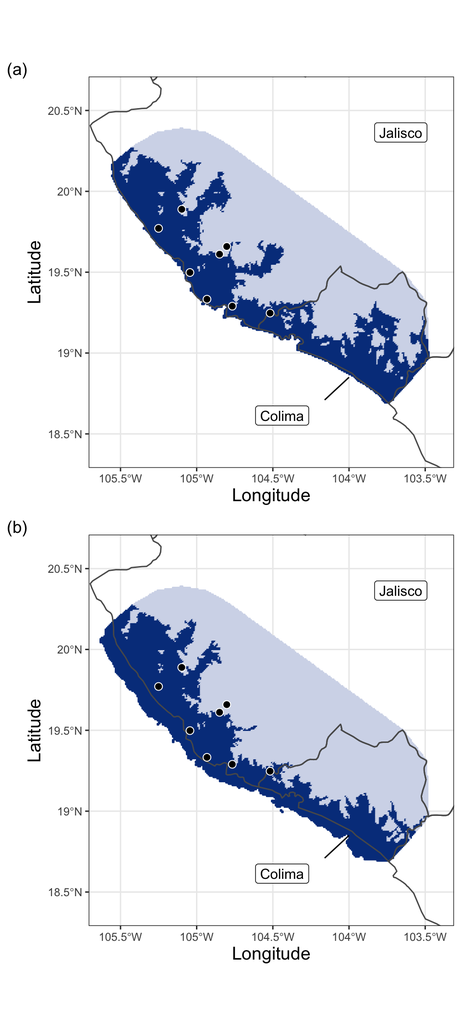

```r
# A basemap of Mexican states for plotting
states <-
  rnaturalearth::ne_states(country = "Mexico", returnclass = "sf")
states <-
  st_transform(states, crs = '+proj=longlat +ellps=WGS84 +datum=WGS84 +no_defs')

# set the coordinate reference system for both raster layers
crs(pred_p10) <- '+proj=longlat +ellps=WGS84 +datum=WGS84 +no_defs'
crs(lgm_p10) <- '+proj=longlat +ellps=WGS84 +datum=WGS84 +no_defs'


# set beginning and end lines for colima label
line_df <- tibble(x1 = -104.16, y1 = 18.71, x2 = -104, y2 = 18.85)

### Current SDM ####
pred_p10_sf <- pred_p10 %>%
  raster::rasterToPolygons() %>%
  st_as_sf()


current_map <- ggplot() +
  geom_sf(data = pred_p10_sf, aes(fill = layer, color = layer)) +
  scale_fill_gradient(low = "#D3D9EA",
                      high = "#043D8B",
                      na.value = "transparent") +
  scale_color_gradient(low = "#D3D9EA",
                       high = "#043D8B",
                       na.value = "transparent") +
  geom_sf(data = states, fill = "transparent") +
  geom_point(
    data = occs,
    aes(x = longitude, y = latitude),
    shape = 21,
    color = "white",
    fill = "black",
    size = 2.5
  ) +
  coord_sf(xlim = c(-105.6,-103.42), ylim = c(18.4, 20.6)) +
  geom_sf_label(
    data = states,
    aes(label = name),
    nudge_x = -0.5,
    nudge_y = -0.5
  ) +
  geom_segment(data = line_df, aes(
    x = x1,
    y = y1,
    xend = x2,
    yend = y2
  )) +
  labs(x = "Longitude",
       y = "Latitude",
       fill = "Suitability") +
  theme_bw() +
  theme(legend.position = "none",
        axis.title = element_text(size = 14))

#### LGM SDM ####
lgm_p10_sf <- lgm_p10 %>%
  raster::rasterToPolygons() %>%
  st_as_sf()

lgm_map <- ggplot() +
  geom_sf(data = lgm_p10_sf, aes(fill = layer, color = layer)) +
  scale_fill_gradient(low = "#D3D9EA", high = "#043D8B", na.value = "transparent") +
  scale_color_gradient(low = "#D3D9EA", high = "#043D8B", na.value = "transparent") +
  geom_sf(data = states, fill = "transparent") +
  coord_sf(xlim = c(-105.6, -103.42), ylim = c(18.4, 20.6)) +
  geom_sf_label(
    data = states,
    aes(label = name),
    nudge_x = -0.5,
    nudge_y = -0.5
  ) +
  geom_segment(data = line_df, aes(
    x = x1,
    y = y1,
    xend = x2,
    yend = y2
  )) +
  geom_point(
    data = occs,
    aes(x = longitude, y = latitude),
    shape = 21,
    color = "white",
    fill = "black",
    size = 2.5
  ) +
  labs(
       x = "Longitude",
       y = "Latitude",
       fill = "Suitability"
       ) +
  theme_bw() +
  theme(legend.position = "none",
        axis.title = element_text(size = 14))


pred_combo <-
  current_map / lgm_map +
  plot_annotation(
    tag_levels = "a",
    tag_prefix = "(",
    tag_suffix = ")",
    theme = theme(
      plot.margin = grid::unit(c(0, 0, 0, 0), "mm"),
      panel.grid.minor = element_blank(),
      panel.background = element_rect(fill = "transparent", colour = NA),
      plot.background = element_rect(fill = "transparent", colour = NA)
    )
  )


fig_out <- here("output", "figures")

ggsave(pred_combo,
       filename = "fig5_sdm_projections.pdf",
       device = "pdf",
       width = 90,
       height = 200,
       units = "mm",
       path = fig_out,
       bg = "transparent"
       )

pred_combo
```

Supplemental Figure 3. MESS maps.

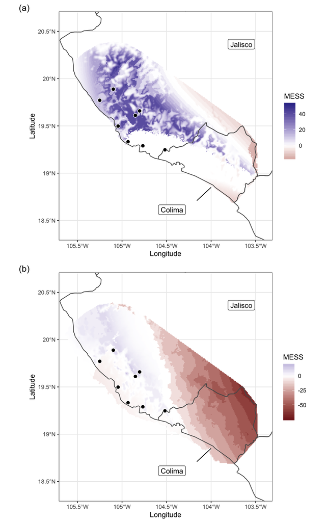

```r
# current mess
current_mess <- raster(here("output", "rasters", "current_mess.tif"))

current_mess_sf <- current_mess %>%
  raster::rasterToPolygons() %>%
  st_as_sf()

current_mess_plot <- ggplot() +
  geom_sf(data = current_mess_sf, aes(fill = current_mess, color = current_mess)) +
  scale_fill_gradient2(na.value = "transparent") +
  scale_color_gradient2(na.value = "transparent") +
  geom_sf(data = states, fill = "transparent") +
  coord_sf(xlim = c(-105.6, -103.42), ylim = c(18.4, 20.6)) +
  geom_sf_label(
    data = states,
    aes(label = name),
    nudge_x = -0.5,
    nudge_y = -0.5
  ) +
  geom_segment(data = line_df, aes(
    x = x1,
    y = y1,
    xend = x2,
    yend = y2
  )) +
  geom_point(
    data = occs,
    aes(x = longitude, y = latitude),
    shape = 21,
    color = "white",
    fill = "black",
    size = 2.5
  ) +
  labs(x = "Longitude",
       y = "Latitude",
       fill = "MESS") +
  guides(color = "none") +
  theme_bw()

# lgm mess
lgm_mess <- raster(here("output", "rasters", "lgm_mess.tif"))

lgm_mess_sf <- lgm_mess %>%
  raster::rasterToPolygons() %>%
  st_as_sf()

lgm_mess_plot <- ggplot() +
  geom_sf(data = lgm_mess_sf, aes(fill = lgm_mess, color = lgm_mess)) +
  scale_fill_gradient2(na.value = "transparent") +
  scale_color_gradient2(na.value = "transparent") +
  geom_sf(data = states, fill = "transparent") +
  coord_sf(xlim = c(-105.6, -103.42), ylim = c(18.4, 20.6)) +
  geom_sf_label(
    data = states,
    aes(label = name),
    nudge_x = -0.5,
    nudge_y = -0.5
  ) +
  geom_segment(data = line_df, aes(
    x = x1,
    y = y1,
    xend = x2,
    yend = y2
  )) +
  geom_point(
    data = occs,
    aes(x = longitude, y = latitude),
    shape = 21,
    color = "white",
    fill = "black",
    size = 2.5
  ) +
  labs(
       x = "Longitude",
       y = "Latitude",
       fill = "MESS"
       ) +
  guides(color = "none") +
  theme_bw()

mess_combo <-
  current_mess_plot / lgm_mess_plot +
  plot_annotation(
    tag_levels = "a",
    tag_prefix = "(",
    tag_suffix = ")",
    theme = theme(
      plot.margin = grid::unit(c(0, 0, 0, 0), "mm"),
      panel.grid.minor = element_blank(),
      panel.background = element_rect(fill = "transparent", colour = NA),
      plot.background = element_rect(fill = "transparent", colour = NA)
    )
  )

ggsave(mess_combo,
       filename = "supp_fig_s3_mess.pdf",
       device = "pdf",
       width = 100,
       height = 210,
       units = "mm",
       path = fig_out,
       bg = "transparent"
       )

mess_combo
```

Figure 6. Isolation by distance scatterplot.

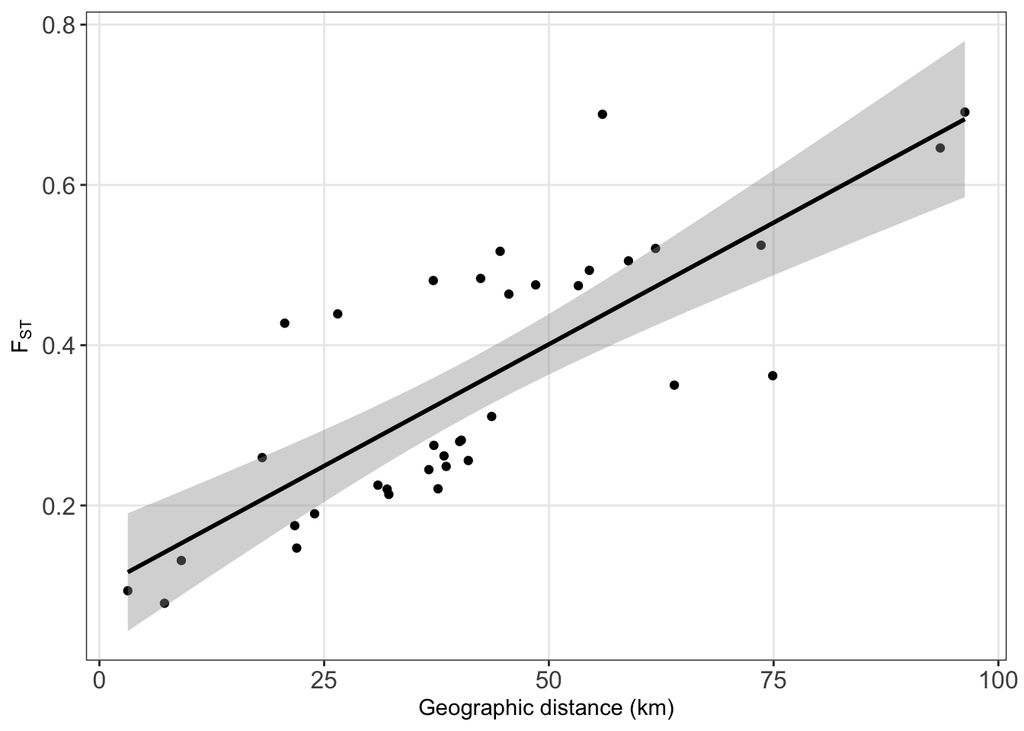

```r
geo_lower <- geo_dist[lower.tri(geo_dist)]
fst_lower <- fst_mat[lower.tri(fst_mat)]

ibd_df <- tibble(geo_dist = geo_lower, gen_dist = fst_lower)

ibd_plot <- ggplot(data = ibd_df, aes(x = geo_dist, y = gen_dist)) +
  geom_point() +
  geom_smooth(method = "lm", color = "black") +
  labs(x = "Geographic distance (km)", y = expression(F[ST])) +
  scale_x_continuous(labels = function(x) x / 1000) +
  theme_bw() +
  theme(axis.text = element_text(size = 12),
        panel.grid.minor = element_blank(),
        plot.margin = margin(2, 3, 2, 2, "mm"))

ggsave(ibd_plot,
       filename = "fig_6_ibd.pdf",
       device = "pdf",
       height = 80,
       width = 120,
       units = "mm",
       path = fig_out
       )

ibd_plot
```

## Session information

Session information for reproducibility.

```r

si
```

[output not shown]

Here is the code for writing the session info to the `doc` folder.

```r
si_path <- here("doc", "session_info.txt")

# write session info to the doc folder
writeLines(capture.output(sessionInfo()), si_path)
```

## Some extra code

Masking code in case a reviewer wants us to mask out extrapolated e-space.

```r
## Code to mask rasters in case I decide to. The LGM has some very minor extrapolation across a fair portion of the map (negative numbers near zero). If I masked these, a fair portion of the map would be removed. There isn't really an objective way to decide what MESS value is too low and the more egregious values lie outside of their current range, so I'm providing the MESS maps as supplementary figures to aid in interpretation.


mess_mask_c <- current_mess

# set all negative values to NA to make this a mask
mess_mask_c[values(mess_mask_c) < -0.001] <- NA # added a small amount to account for imprecision
crs(mess_mask_c) <- '+proj=longlat +ellps=WGS84 +datum=WGS84 +no_defs'

# crop the mess mask
mess_cropped_c <- mess_mask_c %>%
  crop(pred)

# mask the current climate by the mess mask
current_masked <- pred %>%
  mask(mess_cropped_c)

crs(current_masked) <- '+proj=longlat +ellps=WGS84 +datum=WGS84 +no_defs'
```